# Storm Data Analysis for the USA and associated Regions

Dave Robinson

Wednesday, February 18, 2015

## Synopsis:

The purpose of this short summary is to determine what categories of severe storm and weather related events are of most concern as regards to health and safety of the citizens.

The NOAA database contains records that have been collected since 1950. The records contain information on storm damage, injuries and deaths as a time series. However we are not particularly interested in analyzing these issues over time – rather their likelihood of occurrence and possibly allowing users of this report to determine priorities.

In terms of fatalities Tornadoes and heat stood out as the large contributors with Tornadoes being the greatest by far as shown in the following graphs.

Tornadoes were again the leading contributor to injuries with wind, storms and lightening also being significant contributors. Floods and heat also contributed to injuries.

It should be pointed out that regional variations could be significant as coastal areas are far more prone to flooding while affected far less by tornadoes which dominate the picture for damage, death and injuries.

# Data Processing

```r
library("lubridate")
library("dplyr")
library("ggplot2")
library("gridExtra")


sdURL <- "http://d396qusza40orc.cloudfront.net/repdata%2Fdata%2FStormData.csv.bz2"
destFile = "repdata_data_StormData.csv.bz2"

# Remove download for testing only...
# ************************************************************************************
download.file(sdURL, destFile, mode="wb")
# ************************************************************************************

# This works
sd <- read.table(destFile, header=T,sep=",", stringsAsFactors = F)
sd2 <-sd[,c(1:31,37)]

# Setup year and month factors...
sd2$BGN_DATE <- mdy_hms(sd2$BGN_DATE) #, "%m/%d/%Y %h:%M:%S", tz=sd2$TIME_ZONE)
sd2$year <- year(sd2$BGN_DATE)
sd2$month <- month(sd2$BGN_DATE)

g1y <- sd2
groupyr <- factor(sd2$year)
g1y <- data.frame(year_group=groupyr,sd2)
# max(g1y$year)



# -------------
# EVENTS -
# --------------
groupevt <- factor(sd2$EVTYPE)
gev <- data.frame(evt_group=groupevt,sd2)
gev_inj_sum <- summarise(group_by(gev,evt_group), injuries = sum(INJURIES))
gev_fat_sum <- summarise(group_by(gev,evt_group), fatalities = sum(FATALITIES))
gev_pd_sum  <- summarise(group_by(gev,evt_group), propdmg=sum(PROPDMG))

gev_inj_sum <- gev_inj_sum[order(gev_inj_sum$injuries, decreasing=T),]
gev_fat_sum <- gev_fat_sum[order(gev_fat_sum$fatalities, decreasing=T),]
gev_pd_sum <-  gev_pd_sum[order(gev_pd_sum$propdmg, decreasing=T),]


topteninj <- gev_inj_sum[1:10,]
topteninj$evt_group <- factor(topteninj$evt_group)
injlabels <- topteninj$evt_group

toptenfat <- gev_fat_sum[1:10,]

toptenpropdmg <- gev_pd_sum[1:10,]

sum_propdmg_yr <- summarise(group_by(g1y,year_group), propdmg = sum(PROPDMG))
spdyr <- sum_propdmg_yr



sum_fat_yr <- summarise(group_by(g1y,year_group), fatalities = sum(FATALITIES))
sum_inj_yr <- summarise(group_by(g1y,year_group), injuries = sum(INJURIES))
sum_propdmg_yr <- summarise(group_by(g1y,year_group), propdmg = sum(PROPDMG))

# ------------------------
```

## Results

### Injuries

Injuries due to storm and sever weather events are dominated by Tornadoes and other severe storm events followed by floods – also likely due to storms or possibly spring run-off events – followed by Heat events.

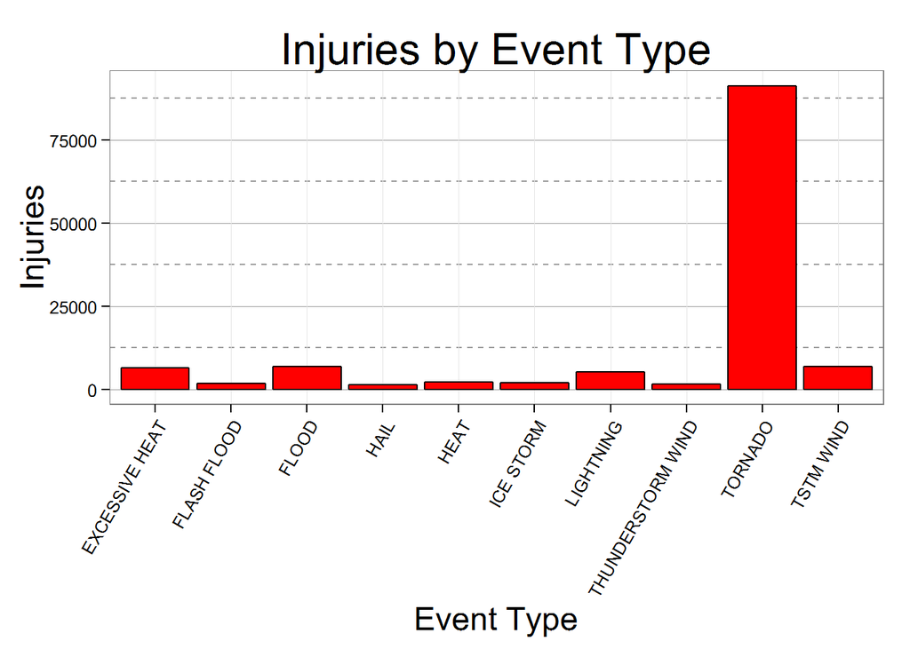

```r
evinjbycat <- ggplot(topteninj, aes(y=injuries, x=evt_group )) +
    geom_bar(stat="identity", fill="red",colour="black") +
    xlab("Event Type") +
    ylab("Injuries") +
    ggtitle("Injuries by Event Type") +
    theme_bw()  +
    theme( axis.text.x = element_text(angle=60, hjust=1),
    panel.grid.major.y= element_line(color="grey60", linetype="solid"),
    panel.grid.minor.y= element_line(color="grey60", linetype="dashed"),
    panel.grid.major.x= element_line(),
    plot.title=element_text(size=rel(2)),
    axis.title.x  = element_text(angle=0, vjust=0.5, size=rel(1.5)),
    axis.title.y  = element_text(angle=90, vjust=0.5, size=rel(1.5))
    )

evinjbycat
```

### Fatalities

Fatalities due to severe weather events are again dominated by Tornado with Heat events and Flood events predominating. Other storm events such as lightening, high winds are also contributors to fatalities over the years 1950 to 2011.

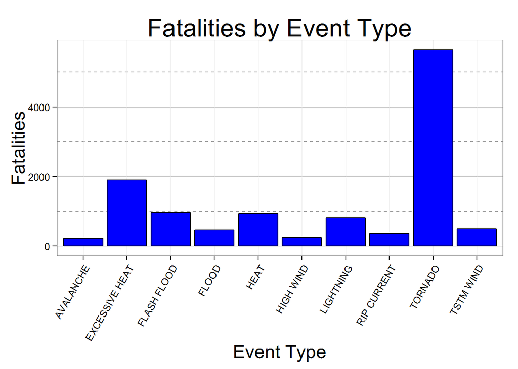

```r
evfatbycat <- ggplot(toptenfat, aes(y=fatalities, x=evt_group )) +
    geom_bar(stat="identity", fill="blue",colour="black") +
    scale_fill_brewer(palette = "Blues") +
    xlab("Event Type") +
    ylab("Fatalities") +
    ggtitle("Fatalities by Event Type") +
    theme_bw()  +
    theme( axis.text.x = element_text(angle=60, hjust=1, size=rel(1)),
           panel.grid.major.y= element_line(color="grey60", linetype="solid"),
           panel.grid.minor.y= element_line(color="grey60", linetype="dashed"),
           panel.grid.major.x= element_line(),
           plot.title=element_text(size=rel(2)),
           axis.title.x  = element_text(angle=0, vjust=0.5, size=rel(1.5)),
           axis.title.y  = element_text(angle=90, vjust=0.5, size=rel(1.5))
           #plot.xlab =element_text(size=rel(1.5))
           )

evfatbycat
```